# On the Qualification of Assays for SAR Development

Intuitive Analytical Methods and Practical Guidelines

Author

Richard M. Nelson, Ph.D.

Date

23 March 2025

The first principle is that you must not fool yourself — and you are the easiest person to fool. So you have to be very careful about that. After you’ve not fooled yourself, it’s easy not to fool other scientists.

— Richard Feynman (1918-1988)

# 1 Preface

THIS monograph concerns how to determine whether an assay is suitable to support the development of structure-activity relationships (SAR) by medicinal chemists for their design and optimization of small-molecule probes and drug candidates. It is crucial to confirm that assays used for SAR-building are fit for this purpose because reliance on unqualified assays undermines compound advancement and can cause costly delays and missed opportunities. The responsibility for confirming assay fitness belongs to the scientists who run them. Without attempting to be exhaustive, the topics in this monograph are those which experience has taught me are important and relevant to qualify assays to support SAR development, some of which are occasionally neglected under the pressure of project demands for data. And while most content will merely underscore what seasoned pharmaceutical researchers fully appreciate, I hope that some usefulness may be gleaned by scientists newly engaged in the worthy pursuit of inventing drugs needed by patients with serious medical conditions.

**Note: SAR definition**

First described by Crum-Brown and Fraser in the 19th century (1), SAR is the relationship between molecular structure and biological effect that serves as the indispensable roadmap chemists follow to define the pharmacophore—the operating molecular structure—and then, by design and testing of analogs, to refine and optimize its potency, selectivity, solubility, lipophilicity, protein binding, membrane permeability, pharmacokinetics, pharmacodynamics, and other properties on the path to designing a viable drug molecule. Among these, potency is the primary property that medicinal chemists leverage to build SAR by bringing to bear their knowledge of biomolecular interactions and small-molecule optimization instincts honed over years of drug development experience.

By its nature, SAR is a complex (2), delicate construct readily compromised by a wobbly assay platform, rendering it incapable of illuminating medicinal chemists’ systematic navigation toward a drug molecule. Successful development of SAR requires that a change made to the structure of a molecule is accurately reflected by its measured activity and is not confounded by assay unreliability.

Biological assays in vitro are fundamental tools of scientific research that have broad utility ranging from determination of catalytic constants in purified-component enzyme reactions to modeling bodily systems using innovative cell and organoid cultures. Assays used to understand drug function are controlled experimental systems in which the effect(s) of perturbagens, such as small molecules, antibodies, and antisense oligonucleotides, can be measured to predict their activity in vivo. The output of a physiologically relevant assay *translates* to humans, often to a specific disease or disorder, and the link from in vitro system to targeted disease has—for phenotypic assays—been dubbed the chain of translatability (3).

Voluminous information about assays can be found in many scientific publications. Specialty journals like *SLAS Discovery* and *Assay and Drug Development Technologies*, as well as several books, such as 4, 5, and 6, are devoted to developing, optimizing, and running reproducible, high-quality cell-based and biochemical assays for drug development. A distinctive resource in this category is the *NIH Assay Guidance Manual*, a freely available eBook that is updated periodically (7).

As illustrated metaphorically in Figure 1, three foundational elements support the quality and reproducibility of an assay’s output, which is often the IC<sub>50</sub> or EC<sub>50</sub> of a test substance. All three legs of assay infrastructure must be well-constructed to support a testing platform capable of facilitating development of sound SAR by medicinal chemists. Major constituents of each supporting leg are listed below.

**Design and optimization**: $~$assay technology and format, microplate type, active component concentrations, pH, buffer, carrier protein concentration, temperature, reaction volume, assembly order, timing, cell selection and density, signal window, DMSO tolerance.

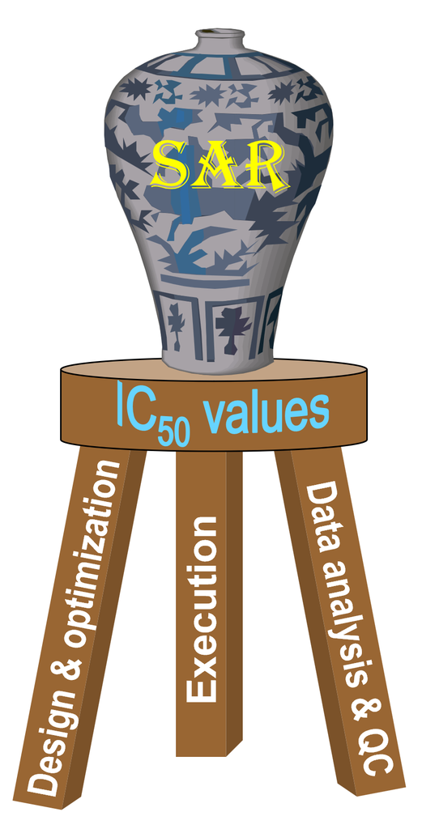

**Figure** 1**.** Assay infrastructure for reliable measurement of inhibitor potency to support developent of SAR.

**Execution**: $~$reagent dispensing and mixing, microplate layout, protein handling procedures, cell culture protocol, test-compound dissolution, storage, and dilution methods.

**Data analysis & quality control**: $~$reference compound $~$IC<sub>50</sub> run charts (8) and distribution histograms (Figure 5, CRC quality metrics), variance of positive and negative control signals and signal window, outlier handling, reproducibility of test-compound potency measurements (Figure 4).

**Note: Potency indices**

The IC<sub>50</sub> is a prevalent measure of potency used in drug development for monotonic assay systems and serves as exemplar potency index throughout this monograph. For cell-based assays with extended run times, an analog of the IC<sub>50</sub>, the GR<sub>50</sub> (growth rate inhibition), has been developed to account for confounding effects of cell growth and division during the assay (9). The same assay quality analyses and metrics apply to both inhibitors and to EC<sub>50</sub> measurements of compounds that stimulate assay activity; special considerations for activator data analysis are described in Section 4.4.

Though applicable to many assay types, the IC<sub>50</sub> is an empirical measure whose underlying molecular mechanisms are not necessarily fully discoverable. As such, it is highly dependent on specific experimental conditions and will often vary more between than within laboratories (10). And while an IC<sub>50</sub> is relatively easy to determine, for some targets and molecular modes of action—covalent inhibitors, for example (11)—relevant mechanistic constants, such as $K_{i}$, $k_{inact}$, $K_{M}$, or $k$<sub>*off*</sub> , may be more appropriate for SAR development, though not necessarily less variable from lab to lab (12, 13).

Certain assay systems display hormetic or multiphasic (non-monotonic) concentration-response relationships which cannot be adequately described by a simple sigmoidal function. Such assay systems require more complex models and indices to quantify the potency of perturbagens (14, 15).

A model often fitted to concentration-response data to determine a test-compound’s IC<sub>50</sub> is the 4‑parameter logistic model (16, p 330):
$$y = LA + \frac{UA - LA}{1 + 10^{(-log_{10}(x) - pIC_{50}) \cdot slope}}
\tag{1}$$

where $x$ = inhibitor molar concentration, $y$ = signal or normalized signal (POC), and the four fitted parameters are:

$LA$ lower asymptote  
$UA$ upper asymptote  
$slope$ slope of curve at its inflection point (the midpoint)  
$pIC_{50}$ negative log<sub>10</sub> molar inhibitor concentration at the midpoint.

Shown in Figure 2, this 4-parameter logistic model describes a symmetrical S‑shaped curve of activity as a function of log<sub>10</sub> inhibitor concentration that is applicable to many concentration-response relationships in biochemical and cell-based assay systems. Its etymology and relationship to the Hill equation and other models are described in 17 and 18, Chapter 10.

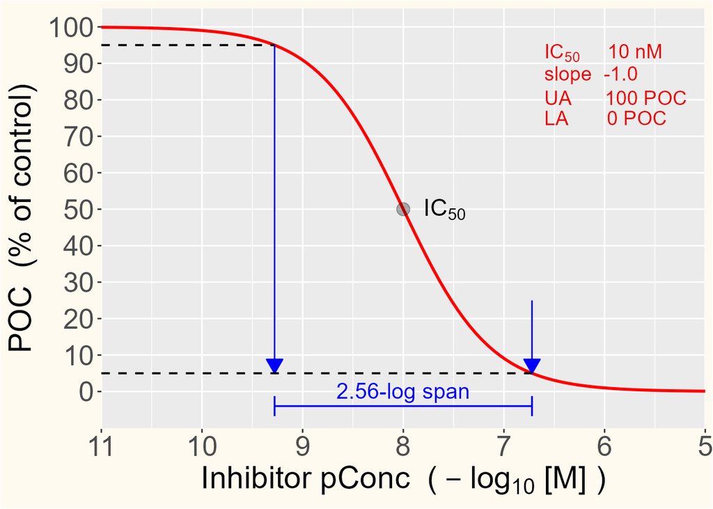

**Figure** 2**.** Plotted 4-parameter logistic function (Equation 1) with parameter values listed in red type. Blue arrows show the inhibitor concentration range encompassing the central 90% of the curve. Experimental concentration-reponse data can yield fitted curves with slopes significantly steeper or shallower than -1.0 that span a correspondingly smaller or larger range of inhibitor concentration.

**Note: Two flavors of IC<sub>50</sub>**

Of the two ways to determine an IC<sub>50</sub> value, the prevailing method and the one used in this monograph is to compute the midpoint (inflection) parameter of the 4-parameter logistic equation (Equation 1) fitted to the concentration-response data using nonlinear least-squares regression (19). This inflection point is also known as the **relative IC<sub>50</sub>** because it can differ from the concentration of compound producing 50% of uninhibited activity. An **absolute IC<sub>50</sub>** may be preferable for assay systems that cannot be fully inhibited or display multiphasic or non-monotonic responses, calculated by interpolation on the fitted CRC of the concentration value at 50 POC.

When assay concentration-response data describe well-formed monotonic curves spanning the full range of activity, as in Figure 8, relative and absolute IC<sub>50</sub> values will be essentially equivalent.

The sensitivity, accuracy, and throughput required of an assay are dictated by its intended purpose. Ideally, the capacity and throughput of primary SAR-driving assays supporting the compound optimization cycle (design, synthesize, test, analyze) allow weekly turnaround of concentration-response testing that matches or exceeds weekly compound output of the medicinal chemistry team working on the project.

Above all, any assay—whatever its purpose or throughput—must be dependable to be useful; that is to say, its output must be *reproducible*, meaning it is characterized by *precision*. Methods to quantify this precision are described in Section 3.

# 2 Resolution Categories

BIOLOGICAL assays in vitro are essential to every phase of drug invention, and they are often the gatekeepers that provide front-line potency assessment of hit and lead molecules. As touched upon in the Preface, one of the most demanding uses for an assay is to provide high-quality activity data which allow medicinal chemists to develop the SAR that informs and guides design and optimization of candidate drug molecules.

Two hallmark attributes of such “SAR-driving” assays are *physiological relevance* (predictive power, translatability) and high *reproducibility* (precision). Establishing an assay’s physiological relevance is out of scope here. To achieve suitable precision typically requires an assay to be robust—that is, tolerant of minor changes in conditions—and together with appropriate sensitivity, its degree of precision establishes in which resolution category it belongs:

- **Quantitative** assays include those suitable to enable development of exploitable SAR;
- **Semi-quantitative** assays provide only rank-order binning of compound activity;
- **Qualitative** assays are limited to a binary (yes/no) readout of compound activity.

Notwithstanding this monograph’s exclusive focus on quantitative assays that can support SAR development, semi-quantitative and qualitative assays make important contributions in other areas of drug development.

# 3 Qualifying Metrics

ASSAY performance can be evaluated in several ways. Many years in the pharmaceutical industry developing and running assays to support compound optimization by drug-invention teams have taught that three practical metrics described below, taken together, reliably indicate whether an assay can effectively support SAR development. Although these three metrics assess interrelated aspects of an assay’s precision, any one by itself can mislead. Each metric consists of an intuitive graphical-statistical analysis that views data quality from a different angle, and their combined perspective paints an accurate picture of assay performance.

**1) Quality of individual concentration-response curves** **(CRC)** represented by the 95% confidence limits ratio of the IC<sub>50</sub> parameter (hereafter abbreviated CLR) determined by nonlinear least-squares fitting of the 4‑parameter logistic model (Equation 1) to concentration-response data sets produced by the assay (Metric 1).

**2) Agreement of n=2 IC<sub>50</sub> measurements** of ≥ 20 active compounds tested in two independent assay runs, quantified using a Tukey mean-difference plot (Metric 2).

**3) Distribution of repeated IC<sub>50</sub> values over time** measured in ≥ 20 independent assays of a single active reference compound (Metric 3).

The following subsections present examples of each of these three analyses and provide—beneath subheadings in Green Typeface—guideline criteria for quantitative assay qualification.

## 3.1 CRC Quality

The dimensionless confidence limits ratio (CLR) was introduced by Charles Poole as a useful measure of precision in the context of sample statistics (20). First applied to concentration-response curves in our labs (to my knowledge), the 95% confidence limits ratio of the best-fitting IC<sub>50</sub> parameter of the 4‑parameter logistic model (Equation 1), is calculated as shown in Equation 2:
$$\text{CLR} = \frac{\text{95\% } CL_{upper} \text{ of fitted }
IC_{50}\text{ parameter}}{\text{95\% } CL_{lower} \text{ of fitted }
IC_{50} \text{ parameter}}
\tag{2}$$

Calculating confidence limits for the parameters generated by nonlinear least-squares curve fitting is more complicated than calculating confidence limits of a population mean, difference, or proportion (21). Fortunately, commercial and open-source software programs, including [GraphPad Prism](https://www.graphpad.com/), R (22), and specialized R packages (23, 24), employ nonlinear fitting algorithms that compute both the symmetric *asymptotic confidence limits* and the asymmetric *profile likelihood confidence limits* of each optimized model parameter. Asymptotic confidence limits were more frequently used used historically because their calculation is less computationally intensive, and for this reason they were used to establish the CLR guideline threshold for SAR-driving suitability described below.

The mathematics and algorithms used to calculate profile likelihood confidence limits (25) are outside the present scope; the simpler asymptotic confidence limits of fitted parameters, including the IC<sub>50</sub>, are calculated using the following equations (26, 27, 28):

$$CL_{lower} = P_i-t \cdot SE_{P_i} \tag{3}$$
$$CL_{upper} = P_i+t \cdot SE_{P_i} \tag{4}$$

where the abbreviations are:

$P_i$ $i$<sup>th</sup> parameter obtained by nonlinear fitting  
$DF$ degrees of freedom, the number of data points minus the number  
of parameters fit by nonlinear regression  
$t$ t distribution value for 95% confidence and $DF$ degrees of freedom  
$SE_{P_i}$ standard error of $P_i=\sqrt{(SSR \div DF)\cdot cov(i,i)}$  
$SSR$ sum of squared residuals $=\sum_{i=1}^{n}(y_i-f(x_i))^2$  
$cov(i, i)$ $i$<sup>th</sup> diagonal element of the covariance matrix.

Their different computational methods aside, it is worth noting that as concentration-response data quality increases, asymptotic and profile likelihood confidence limits—and CLRs—*converge*, as can be shown by fitting the 4‑parameter logistic equation to many simulated concentration-response data sets of varying quality.

The log<sub>10</sub> of the CLR represents the width of the fitted IC<sub>50</sub> confidence interval plotted on a logarithmic concentration scale, with CLR = 10 spanning one log of compound concentration. The calculated CLR can assume values from  
1${\text{ to } \infty}$, with high-quality curve fits returning CLRs < 5 (see Figure 3 and CRC Quality Criteria below).

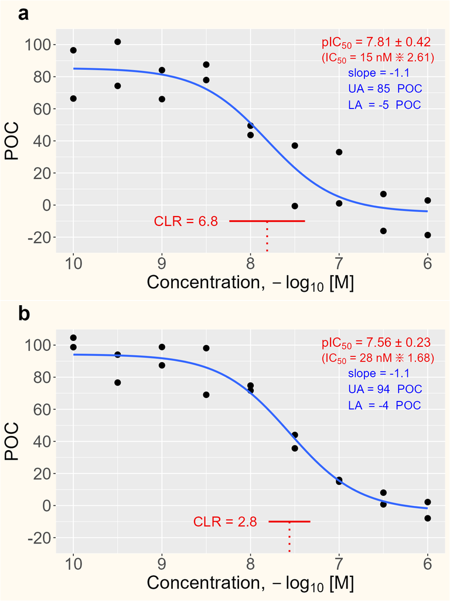

**Figure** 3**.** Nonlinear curve fitting of the 4-parameter logistic model (Equation 1) to simulated concentration-response data with different levels of variability. The vertical dotted red line shows the pIC<sub>50</sub> and the horizontal solid red line shows the pIC<sub>50</sub> 95% confidence interval. The corresponding IC<sub>50</sub> is in parentheses beneath the pIC<sub>50</sub> at the top right corner of each plot.  
**(a)** CRC with CLR > 5, outside the acceptable curve quality range.  
CL<sub>lower</sub> = 5.9 nM (pConc = 8.23)  
CL<sub>upper</sub> = 40 nM (pConc = 7.39)  
**(b)** CRC with CLR < 5, within the acceptable curve quality range.  
CL<sub>lower</sub> = 16 nM (pConc = 7.79)  
CL<sub>upper</sub> = 46 nM (pConc = 7.33)

The CLR in this context is a concise indicator of CRC quality that integrates multiple facets of the model’s fit to the data and, by so doing, accurately represents the quality of the concentration-response data set itself. Because it is unitless, the CLR simplifies comparison of IC<sub>50</sub> confidence across different potency levels and assays. Moreover, the CLR relates directly to the potency index of interest—the IC<sub>50</sub> or EC<sub>50</sub>—making it more intuitive than commonly used goodness-of-fit statistics.

Another assay metric, the Z’-factor, not to be confused with the z-statistic, was designed to flag performance dips in large high-throughput screening campaigns by aggregating signal window and control signal variability in a single unitless number (29). Sometimes employed outside its domain, the Z’‑factor is not useful for evaluating or troubleshooting the relatively small number of microplates and control wells in typical CRC assays, for which run charts (8) are better suited, and it is immaterial to the evaluation of CRC quality. Other methods to measure the variability of biological assays and their acceptance are desscribed in references 30 and 31.

At this point in the discussion of quality metrics it is prudent to remember a cardinal precept of data analysis—namely, *there is no substitute for* *visualization*. No summary statistic(s) can eliminate the need for careful inspection of IC<sub>50</sub> curves by an experienced assay scientist. Quality metrics and statistics, while informative, are best used in concert with plot examination to confirm the credibility of each CRC in the context of the assay’s particular biochemistry and biology.

—— CRC Quality Criteria ——

[1] Greater than 80% of independent IC<sub>50</sub> values determined in ≥ 5 test occasions return *untuned* CLR values < 5, where *untuned* means none of the four model parameters is fixed and no outlier data points are removed to improve the fit. Fixing one of the model parameters or removing multiple errant data points will result in underestimation of the CLR so that it no longer accurately reflects CRC quality and, by extension, assay data quality.

The CLR quality threshold of 5 was derived empirically using asymptotic confidence intervals of fitted curves to 10- or 11-point duplicate concentration-response data at 3-fold or 3.1623-fold (half log) dilution steps (see CRC fine points below). Use of profile likelihood confidence intervals, different inhibitor concentration number or spacing, or a different number of replicates will affect the IC<sub>50</sub> CLR, but it will nonetheless remain a dependable aggregate indicator of both concentration-response data quality and the model’s goodness of fit to the data.

[2] The absolute value of the $slope$ parameter of Equation 1 fitted to the concentration-response data is between 0.6 and 3.0. Slopes outside of this zone can be caused by several factors and are often associated with large IC<sub>50</sub> CLRs. For instance, low slopes can be the result of compound carryover during serial dilution, or of a complex non-monotonic MOA. High CRC slopes can signal cytotoxicity or the involvement of amplified pathways, and can also be caused by a potent inhibitor whose true IC<sub>50</sub> is less than one half of its target’s concentration in the assay system—a resolution limit sometimes called the “wall” of the assay.

## 3.2 pIC<sub>50</sub> Agreement

The Tukey mean-difference plot was invented by John W. Tukey in the 1950s to visualize reproducibility and quantify agreement of multiple pairs of measurements (32, pp. 22-23, pp. 150-151; 33). The plot was popularized by Bland and Altman in 1986 to assess concordance of two different clinical assays measuring the same analyte (34); later Eastwood et al. (35) used the geometric mean (Equation 11) and ratio of IC<sub>50</sub> values (congruous with the arithmetic mean and difference of pIC<sub>50</sub> values) to generate a plot identical in form to a mean-difference plot of pIC<sub>50</sub> values. A Tukey mean-difference plot of pIC<sub>50</sub> values generated in two runs of a cell-based assays is shown in Figure 4.

The Tukey mean-difference plot is superior to the more common n<sub>1</sub> vs n<sub>2</sub> scatter plot and squared correlation coefficient R<sup>2</sup> (Equation 7) to assess agreement because it allows easier visualization and quantitation of deviation from n<sub>1</sub> = n<sub>2</sub>, and because it is not skewed by the range or distribution of pIC<sub>50</sub> values. Nevertheless, to ensure that mean-difference quality metrics reflect assay performance across the potency range of interest and detect any systematic changes across this range, it’s best if the IC<sub>50</sub> values of test compounds span two or more orders of magnitude. This may necessitate repeating the analysis when compounds spanning a suitable potency range have been identified.

—— pIC<sub>50</sub> Agreement Criteria ——

[1] The mean difference of > 20 pairs of independently determined pIC<sub>50</sub> values is within 0.0 ± 0.1 (antilog ratio range 0.79 to 1.26).

[2] The limits of agreement (± 2-SD) of the mean of pIC<sub>50</sub> differences are less than ± 0.8 (antilog ratio range 0.16 to 6.31).

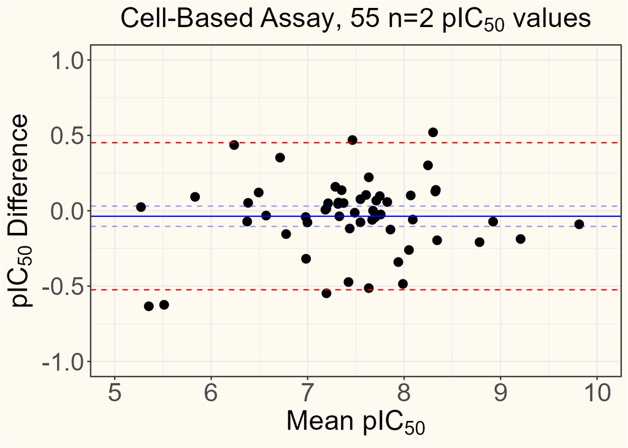

**Figure** 4**.** Tukey mean-difference plot of 55 pairs of pIC<sub>50</sub> values generated in two independent runs of a cell-based assay. The solid blue line is the mean pIC<sub>50</sub> difference (-0.037, antilog = 0.92), the dashed blue lines are its 95% confidence limits, and the dashed red lines are the mean difference ± 2‑SD (0.45 and -0.52, antilogs = 2.8 and 0.30). The mean and difference of each pair of pIC<sub>50</sub> values were calculated in order of the test occasions to generate the plotted data points.

## 3.3 pIC<sub>50</sub> Distribution

The distribution of many IC<sub>50</sub> determinations for a test compound over time provides a high-fidelity picture of an assay’s performance, though practical considerations limit this analysis to one or two reference compounds that are tested in every run of the assay.

The three histograms in Figure 5 show the distribution of accumulating pIC<sub>50</sub> values of a reference compound determined in a cell-based assay over several years. To reflect assay performance accurately, histogram analysis should include no fewer than 15 pIC<sub>50</sub> values, preferably 20 or more. Although more values better resolve the distribution’s normality as assessed by its skewness and kurtosis, 20 values estimate well the mean pIC<sub>50</sub> returned by sample sizes 5 and 25 times larger.

—— pIC<sub>50</sub> Distribution Criteria ——

[1] The distribution of pIC<sub>50</sub> values approximates a Gaussian (normal) distribution (Equation 5).

[2] A 2-SD interval < 1 for the distribution of > 20 pIC<sub>50</sub> values  
(2-SD IC<sub>50</sub> ratio < 10).

When a suitable reference compound is not available in the early phase of a drug invention project, this analysis will necessarily be postponed until such a compound has been identified and tested multiple times.

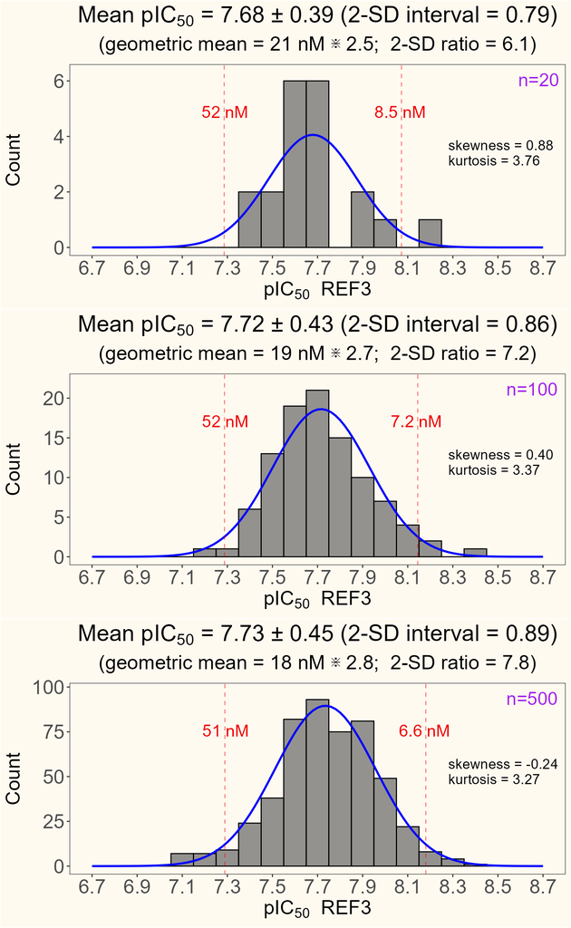

**Figure** 5**.** Histogram plots of pIC<sub>50</sub> values of reference compound REF3 tested in 20 *(top plot)*, 100 *(middle plot)*, and 500 *(bottom plot)* independent runs of a cell-based ex vivo assay (bin size = 0.1). Red dashed lines are ± 2‑SD from the mean. The blue curve is the best-fitting normal (Gaussian) frequency distribution (Equation 5).  
Though the distribution, mean, and 2-SD interval of the mean of 20 pIC<sub>50</sub> values (top plot) are concordant with those of the larger samples (middle and bottom plots), sample skewness and kurtosis values of the larger samples better approximate those of an ideal normal distribution: 0 and 3, respectively (36).

# 4 Operational Advice

SECTION 4 highlights five considerations for the practice of performing SAR-driving assays and analyzing their data. The first two are exhortations about variability; the last three are practical points about CRCs, activator analysis, and comparing potency values from different assays.

## 4.1 Criticality of n ≥ 2

Among several reasons for adhering to a best-practice standard of n=2 IC<sub>50</sub> determinations, the most compelling may be a statistical argument based on the normal distribution of repeated pIC<sub>50</sub> values, shown in idealized form in Figure 6 and in a real example above in Figure 5. Many quantities in nature in addition to IC<sub>50</sub> values distribute log-normally (37), which means their logarithms follow a normal (Gaussian) distribution described by the probability density function (21, p 45),

$$y=\frac{1}{\sigma\sqrt{2\pi}}e^{-(x-\mu)^2 \div 2\sigma^2}
\tag{5}$$

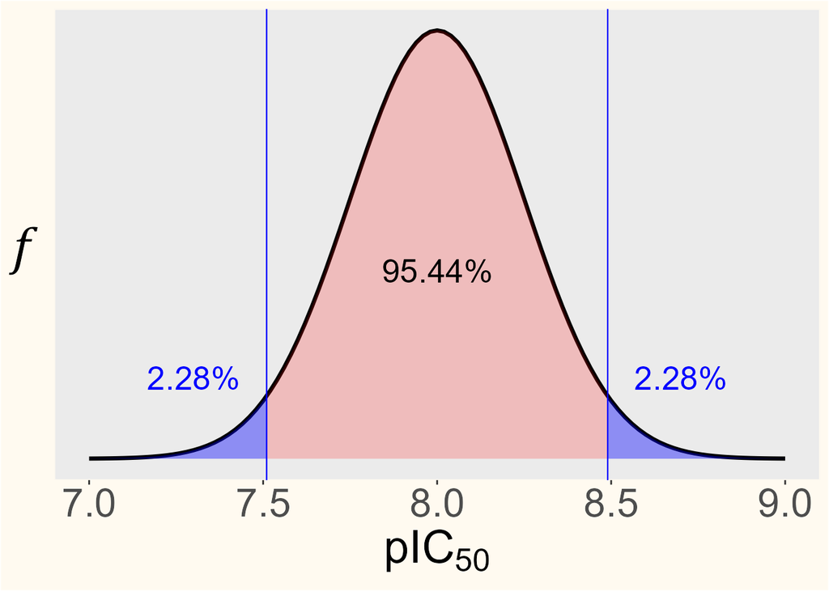

**Figure** 6**.** Idealized Gaussian pIC<sub>50</sub> distribution of a quantitative assay with *μ* = 8.0 and $\sigma$ = 0.25. The ordinate, $f$, is the frequency of occurrence. Vertical blue lines are ± 2‑SD from the mean, and percentages show the expected frequency of shaded areas within (pink) and beyond (blue) 2‑SD of the mean.

where  
$y$ = $f$, the frequency of occurrence,  
$\mu$ = population mean,  
$\sigma$ = population standard deviation, and  
$x$ = pIC<sub>50</sub>.

Given this distribution, the probability that a single pIC<sub>50</sub> measurement for a compound will poorly represent the true mean by falling in the blue areas of Figure 6 beyond 2-SD from the true mean is 4.56%, or 1 in 22, which is not a particularly rare event. The probability of a second measurement of the same compound returning a pIC<sub>50</sub> in the same tail region of the distribution as the initial pIC<sub>50</sub>, and consequently not moving the mean of the two values closer to the true mean, is 4.56% $\times$ 2.28% $=$ 0.104%, or 1 in 962, which *is* a rare event. Table 1 shows the probability of a misleading pIC<sub>50</sub> value in a single test or mean pIC<sub>50</sub> of two or three independent tests, as a function of the number of compounds tested in the assay instances.

**Table 1.** The probability, in a test set of *n* compounds, of observing one, P(1); two, P(2); and three, P(3) *misleading* pIC<sub>50</sub> values for one compound *(> 2-SD in the same direction from the theoretical true mean)* is $P_n=1-(1-P)^n$.  
$P$ was determined from the Gaussian distribution as described in the text.

| *n* | P(1) | P(2) | P(3) |
| --- | --- | --- | --- |
| 1 | 0.046 | 0.001 | 4.9e-08 |
| 10 | 0.37 | 0.01 | 4.9e-07 |
| 20 | 0.61 | 0.021 | 9.9e-07 |
| 40 | 0.85 | 0.041 | 2.0e-06 |

As this statistical argument makes clear, it is highly likely that the mean of two pIC<sub>50</sub> values (or the geometric mean of two IC<sub>50</sub> values) will be reasonably close to the true mean, and therefore will not confound SAR generation or mislead chemists to abandon promising compounds or pursue dead-end structures. Additional independent IC<sub>50</sub> measurements will further increase confidence in the proximity of the geometric mean IC<sub>50</sub> value to the true mean. In practice, multiple IC<sub>50</sub> determinations are called for when the first two values appear unusually disparate or when potency in vitro will be a determining factor in setting a compound’s dosing schedule in vivo.

In conclusion, the substantially decreased risk of misleading medicinal chemists and confounding their SAR is well worth the relatively modest cost, time, and effort required to determine IC<sub>50</sub> values in two or more independent assay runs.

## 4.2 Survivorship bias

This monograph’s leitmotif is the importance of carefully qualifying an assay’s suitability to support SAR development by medicinal chemists. Needless to say, this assay qualification process must be objective to be valid. One practice that undermines objectivity is the imposition of a potency validation gate for each IC<sub>50</sub> determination based solely on its proximity to a previous value or mean of values (to be within 3‑fold, e.g.). This misguided practice is similar to masking outlier concentration-response data points to improve CRC fit statistics except that the masked data points remain visible on the plot, whereas these invalidated IC<sub>50</sub> values vanish without trace.

[figure not shown]

**Figure** 7**.** Returning U.S. WWII bomber with damage indicated by red circles (38).  
Whereas some military analysts suggested that the damaged areas should be armored more heavily before sending planes on bombing runs, the statistician Abraham Wald included survivorship bias in his calculations about how to minimize bomber losses to enemy fire. Wald proposed reinforcement of areas where the returning aircraft were unscathed, inferring that planes hit in those areas were the ones most likely to be lost (39).

Potency gating, however well intentioned, should be avoided because it leads inevitably to two undesirable consequences. First, since the reproducibility of surviving IC<sub>50</sub> values returned to the database will, by self-fulfilling prophecy, be whatever the gating criterion imposes, the apparent variability of the assay—an artifact arising from artificial selection—will fully accomplish the assay scientist’s self-fooling via survivorship bias (Figure 7). Second, on the predictably probable occasions when the first-determined IC<sub>50</sub> of a compound is ≥ 2-SD from the true mean (see above), the gating process will become unbalanced and install a misleading IC<sub>50</sub> value in the database. By masking the true variability of the assay and—even worse—displaying values for some compounds far from their true means, potency gating poses a real danger that contemporaneous and future assay scientists, medicinal chemists, and other data miners will be misled.

The best approach when faced with disparate qualified IC<sub>50</sub> values is to make additional independent determinations (see above section about the Criticality of n ≥ 2). With more determinations, the pIC<sub>50</sub> distribution will better reflect the assay’s variability and the geometric mean will approach its true IC<sub>50</sub>.

## 4.3 CRC fine points

Execution

A CRC with $slope$ = 1 spans 5% to 95% inhibitory activity across approximately 2.5 logs of inhibitor concentration (Figure 2). A compound dilution series that covers twice this range or more will accommodate well-defined fitted curves across a reasonably wide range of IC<sub>50</sub> values before re-testing at a lower starting compound concentration becomes necessary. A suitable concentration range can be achieved using ten serial or direct 3-fold dilutions to make 11 solutions spanning nearly 5 logs of compound concentration. Concentration spacing larger than 4-fold is not recommended because of diminished IC<sub>50</sub> precision.

Acoustic pipetting is the optimal technology to prepare compound dilutions in microplates (40, 41). Acoustic droplet ejection is superior to air- or positive-displacement pipetting because of its unsurpassed accuracy and precision, and because it makes practical the generation of direct dilutions from a single stock solution, thereby avoiding known liabilities of serial dilution, such as carryover and lack of independence of diluted solutions.

Replicates

There are several levels of replication (42), but typical bioassay replicates consist of the same assay reaction assembled in separate microplate wells of the same assay run—often referred to as technical replicates. For assays qualified to support SAR, two replicate wells at each test compound concentration are sufficient for high-quality CRC fitting. The best practice is to perform curve fitting to the replicate data values themselves, not to the mean values of replicates. While replicate independence is assumed by nonlinear least-squares curve fitting (16, p. 334), variability of replicate measuremets is a useful indicator of assay performance that also provides redundancy when an obvious outlier needs masking. In addition to obscuring replicate variability, use of the mean signal of replicates conceals the number of replicates at each compound concentration, and unweighted curve fitting to signal means from different replicate numbers can produce invalid fitted parameter confidence intervals (43).

**Note: Statistical aggregation of ≥ 3 IC<sub>50</sub> values**

Because repeated IC<sub>50</sub> determinations follow a log-normal distribution (Figure 5, Figure 6), the corresponding pIC<sub>50</sub> values may be summarized in a straightforward way as their *arithmetic* mean (Equation 10) and standard deviation (Equation 8): $\bar{x}$ ± SD. It’s more complicated for non-logged IC<sub>50</sub> values, where the *geometric* mean (geomean for short, Equation 11) of the IC<sub>50</sub> values can be followed, in square brackets, by the asymmetric lower and upper 1-SD bounds separated by a comma:
$$\text{geomean}\left[ 10^{(-\bar{x}+SD)},10^{(-\bar{x}-SD)} \right]$$

Alternatively, the seldom encountered geometric SD—a dimensionless factor—may be provided following the geometric mean IC<sub>50</sub> and a multiply/divide symbol for calculation of the 1-SD bounds: $\text{geomean}\divideontimes\text{geoSD}$ (see subtitles of plots in Figure 5, e.g.). The geoSD is the antilog of the SD of mean pIC<sub>50</sub> values: $\text{geoSD}$ = $10^{\text{SD}}$.

Appropriate aggregation of repeated pIC<sub>50</sub> or IC<sub>50</sub> values includes SD or SD bounds, respectively, which are *descriptive* statistics of variance. By contrast, the standard error of the mean (SEM) should *not* be used because it is an *inferential* statistic that does not reflect variance of the aggregated data (see Section 8.2). Graphical representation of repeated pIC<sub>50</sub> or IC<sub>50</sub> measurements (e.g., a jitter plot) should show all individual values whenever compatible with clarity.

IC<sub>Z</sub> for Z ≠ 50

An alternative potency index to the IC<sub>50</sub>—such as the IC<sub>75</sub> or IC<sub>90</sub>—may sometimes be appropriate for compound optimization or to guide dosing in vivo. These indices and their confidence limits can be calculated by fitting Equation 6 to the concentration-response data (44). In this equation, the expression bracketed in blue type replaces $pIC_{50}$ in Equation 1 and includes the potency parameter $pIC_{Z}$, where $Z$ is the alternative percent inhibition.
$$y = LA + \frac{UA - LA}{1+exp10 \left( \left[ -log_{10}(x) -
\color{blue}{ \left\{ pIC_{Z} - \frac{1}{slope}
\cdot log_{10}(\frac{Z}{100-Z}) \right\} } \color{black} \right]
\cdot slope \right) }
\tag{6}$$

It is worth noting that the CLR of a variant potency index will be larger than the IC<sub>50</sub> CLR in proportion to the variant index’s distance from the IC<sub>50</sub>, as shown in Figure 8.

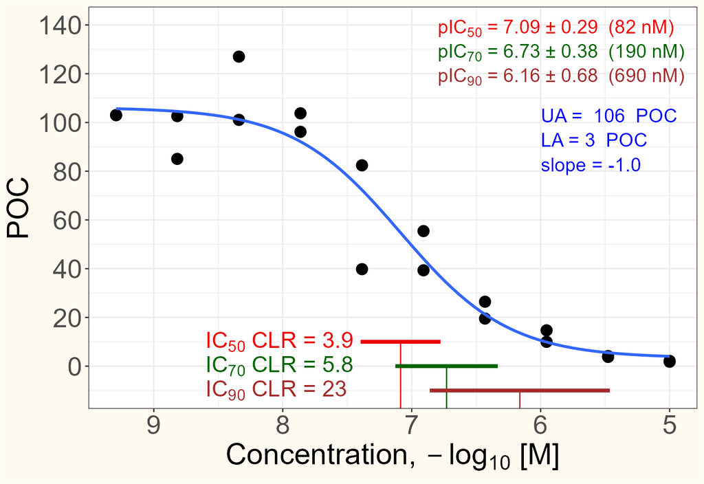

**Figure** 8**.** Nonlinear least-squares fitting of Equation 6 to conentration-response data to compute the pIC<sub>50</sub> (red), pIC<sub>70</sub> (green), and pIC<sub>90</sub> (brown) parameters in the upper right corner ± 95% confidence intervals (antilog IC<sub>Z</sub> values in parentheses). Correspondingly colored vertical and horizontal lines at the bottom show IC<sub>*Z*</sub> values and their 95% confidence intervals, respectively. The three shared parameters of the fitted curve are in blue text.

A different method to calculate activity levels other than 50% is to use a fixed multiple of the IC<sub>50</sub>. This method should be used cautiously, however, because the same IC<sub>50</sub> multiplier will represent different levels of inhibition for compounds whose CRC slopes differ signficantly.

Activity scale

Although CRC plots of inhibitor data often employ a percent inhibition scale on the ordinate, a POC scale has the intuitive advantage that curves slope downward with increasing inhibitor concentration and upward with increasing activator concentration. And unlike percent inhibition, the POC scale accommodates both inhibitor and activator curves, simplifying graphical analysis across many assays and where either type of modulator may be encountered in the same assay.

Significant figures

IC<sub>50</sub> variability arises from measurement (instrument) imprecision and biological variation, and their combined magnitude is such that bioassay activity measurements rarely support more than two significant figures. Roughly speaking, two significant figures means that confidence is high for the first digit and low for the second, and IC<sub>50</sub> and EC<sub>50</sub> values should be rounded accordingly before reporting and storing them in a database. A pIC<sub>50</sub> with two-digit mantissa faithfully produces, by antilog and rounding, the corresponding two-significant figure IC<sub>50</sub>. Even better would be to standardize on two-digit pIC<sub>50</sub> values to eliminate log-antilog interconversion and rounding, and to simplify statistical aggregation and reporting, among other advantages (45).

Signal normalization

Normalization of assay signal to POC, percent inhibition, or fractional activity is a common practice because it facilitates comparison of inter-assay and intra-assay CRCs. Signal normalization, however, comes at a cost of making important assay information invisible on CRC plots. For example, normalization hides both the baseline signal level—typically subtracted before normalization—and the absolute signal window size. Moreover, signals in control wells on outer edges of a microplate can be affected by evaporation and temperature gradients that skew the normalized activity of internal wells. Nonetheless, provided that absolute signals on assay microplates are unfailingly monitored, the convenience of normalization outweighs its drawbacks in most circumstances.

Confounding compounds

Not only unqualified assays but troublesome test compounds themselves can confound the generation of valid SAR. Such compounds may interfere with assays because they are cytotoxic, affect many targets, or perturb assay technology, among other characteristics, and they may even produce reasonably well-formed CRCs. These chemical trouble makers, commonly referred to as pan-assay interference compounds (PAINS), have been well documented in the scientific literature (e.g., 46, 47, 48). An especially insidious source of assay interference is the presence of one or more metal ions carried through compound synthesis and purification. Such metal ions lurking in compound stock solutions can affect cells or assay technologies and produce artifactual CRCs, even at low concentrations (49).

Coherent SAR is itself a revelatory diagnostic for assay readout artifacts caused by test compounds, as highlighted by Dahlin et al. (48): “SAR is one of the most important yet least appreciated arbiters of nuisance activity. The most frustrating cellular nuisance compounds usually exhibit the following behaviors: weak-to-moderate activities, partial selectivity, imperfect SAR, and equivocal counter-screens.”

## 4.4 Activator analysis

The chief distinguishing feature of activator concentration-response data analysis compared to inhibitor analysis is the uncertainty about an assay system’s maximal attainable effect level. Whereas maximal *inhibition* typically equals the activity of the assay’s negative control (inverse agonism or cell growth effects excepted), the highest possible *activation* level of an assay system is often not known definitively, and this uncertainty can complicate accurate determination of test compound potency (EC<sub>50</sub> or midpoint) and efficacy (maximal effect or UA), particularly for low-potency compounds. Test compound activation levels can be normalized to a reference agonist, but this does not solve the problem posed by partial curves of test compounds whose maximal activation may differ from that of the reference agonist.

When the upper asymptote of an activator CRC is not well defined by the data, uncertainty of both the EC<sub>50</sub> and efficacy are elevated, as illustrated in Figure 9. The extent to which upper asymptote ambiguity affects the reliability of computed efficacy and potency values can be gauged by the EC<sub>50</sub> CLR and the confidence limits *difference* (CLD) of the UA, fitted without parameter constraint, as illustrated by comparing upper and lower plots of Figure 9. One practical option in this circumstance of uncertain UA is to use an absolute potency index at a selected activity above the control ligand (see horizontal purple dashed line in Figure 9b). This method can be especially useful for less potent compounds being optimized early after their identification by a high-throughput screen.

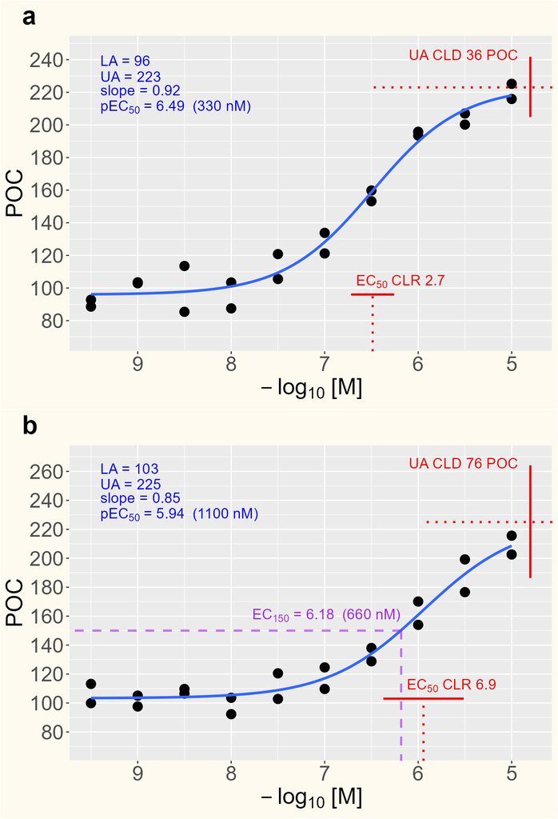

**Figure** 9**.** Nonlinear fits of Equation 1 to activator concentration-response data sets. The solid red lines show the confidence intervals for the fitted UA and EC<sub>50</sub> parameters (dotted red lines).  
**(a)** Activator data that well define the UA (efficacy), as indicated by the small UA CLD and EC<sub>50</sub> CLR.  
**(b)** Activator data that ill define the UA (efficacy), having large UA CLD and EC<sub>50</sub> CLR values. The dashed purple lines show the concentration resulting in absolute activity 50% above the baseline activation.

## 4.5 IC<sub>50</sub> comparison

Compound optimization triage funnels usually include both purified-component (biochemical) and cell-based assays, and—inevitably—potency measurements of compounds in these assay types of vastly different complexity are compared. Correspondence of test compound potency in biochemical and cell-based assays can provide indirect evidence of target engagement in the immensely more complex cell-based system, but a lack of perfect correspondence should be interpreted carefully. The complexity gap can cause potency shifts in cell-based assays due to differential target exposure caused by membrane permeability, off-target binding opportunities, metabolism, efflux pumps, compound partitioning in organelles, or by a cell-specific conformation of the molecular target. Moreover, nonspecific binding to proteins and/or assay microplates in either cell-based or biochemical assays increases with compound lipophilicity, and can result in variable underestimation of true compound potency that will confound SAR if not accounted for (50).

If an x-y scatter plot is used to compare the potency results of compounds in two assays, the logarithms of molar IC<sub>50</sub> (or pIC<sub>50</sub>) values should be plotted and both the correlation coefficient (R) and the coefficient of determination (R<sup>2</sup>) should be interpreted cautiously as reliable indicators of correspondence because of their sensitivity to both the range and distribution of values (51).

Another way to compare pIC<sub>50</sub> values (or their means) from different assays is to plot compound ID on a categorical x-axis and pIC<sub>50</sub> on the y‑axis, with compounds ordered by pIC<sub>50</sub> values in one of the assays, as shown in the example in Figure 10. In this example, as is often but not always the case, most compounds appear less potent in the cell-based assay. In this example, most compounds’ IC<sub>50</sub> values in the cell-based assay are higher by a factor of 4 to 16 than their IC<sub>50</sub> values in the biochemical assay. That some compounds, such as C-13, C-3, and C-22, appear nearly equipotent in the two assays should be interpreted with care, and may be due to one or more of the factors arising from the assay complexity differential mentioned above. An additional consideration, not shown in Figure 10, is that means of small samples typically have wide confidence intervals and confidence intervals for the ratios of such means can be very large indeed.

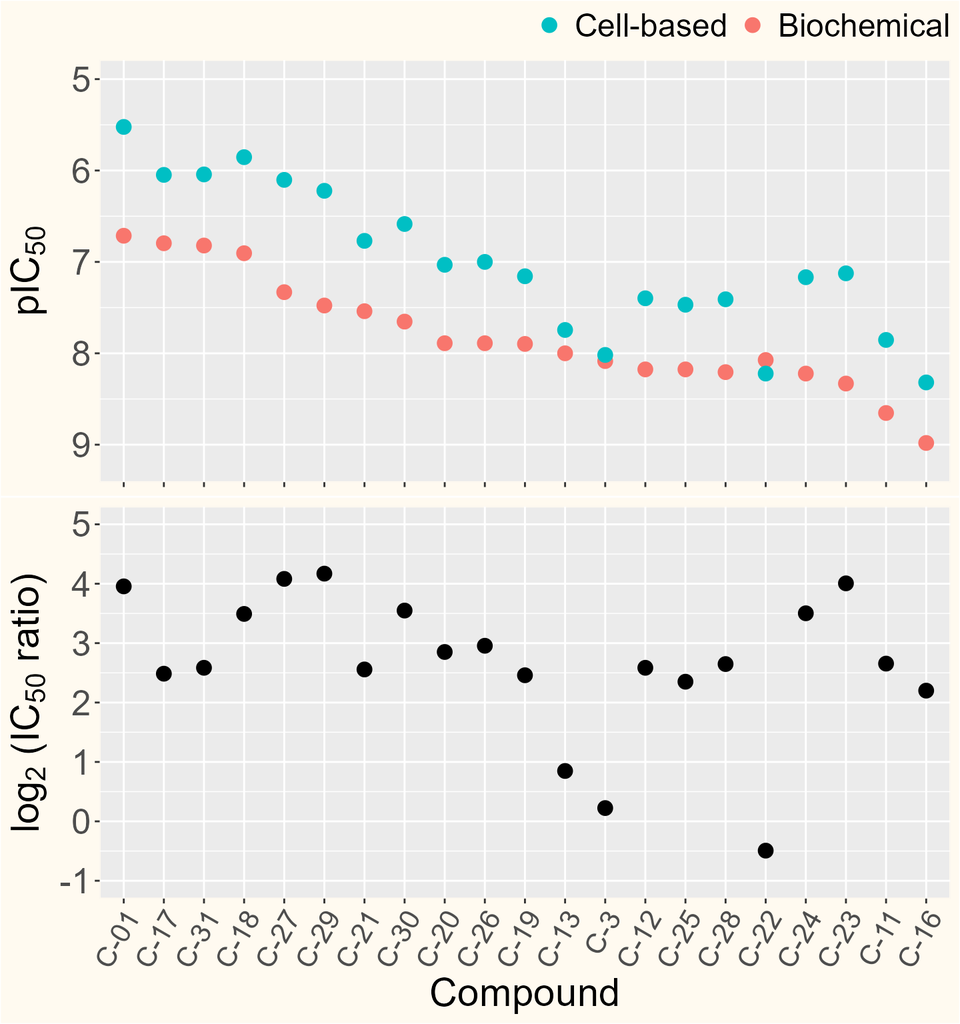

**Figure** 10**.** Comparison of inhibitor pIC<sub>50</sub> values in cell-based and biochemical assays *(upper plot)* and log<sub>2</sub>(cell IC<sub>50</sub>÷ biochemical IC<sub>50</sub>) *(lower plot)*. Compounds are ordered from low to high potency in the biochemical assay.

# 5 Closing

O F necessity, consumers of potency data generated in physiologically relevant bioassays—especially medicinal chemists building SAR—will use the IC<sub>50</sub> values provided to them. This inescapable reliance affixes the onus on assay scientists to ensure in a rigorous way that their assays relied upon to develop SAR are up to the task. The methods and metrics described above can confirm SAR-driving suitability so that assay scientists avoid the adverse consequences of failing to follow Feynman’s first principle.

# 6 Acknowledgements

RENDERING this document in HTML was done with Quarto (52) and R (22). The following R packages were also used: **ggplot2** (53) to generate plots, **minpack.lm** (23) for nonlinear least-squares curve fitting using the Levenberg-Marquadt algorithm, **nlstools** (24) for parameter confidence limits, and **moments** (54) to calculate skewness and kurtosis.

The Richard Feynman quotation epigraph is from his 1974 commencement address at Caltech.

I am indebted to Dr. Daniel Goldberg at the Bill & Melinda Gates Foundation, Dr. Peter White at Paraza Pharma, and Dr. John Proudfoot at Discoverybytes for kindly offering to read drafts of this monograph and for their thoughtful comments and suggestions, which led to a much improved final product. Of course any mistakes are entirely my own.

Finally, I am immensely grateful for numerous former colleagues at Cutter Laboratories, Amgen, Boehringer Ingelheim, and Biogen, in whose excellent company I was privileged to pursue drug invention over the course of my career in the pharmaceutical industry.

# 7 References

1.

Crum-Brown, A., and Fraser, T.R. (1865) The connection of chemical constitution and physiological action. *Trans R Soc Edinb*. **25**, 257

2.

Wassermann, A. M., Wawer, M., and Bajorath, J. (2010) [Activity Landscape Representations for Structure−Activity Relationship Analysis](https://doi.org/10.1021/jm100933w). *Journal of Medicinal Chemistry*. **53**, 8209–8223

3.

Moffat, J. G., Vincent, F., Lee, J. A., Eder, J., and Prunotto, M. (2017) [Opportunities and challenges in phenotypic drug discovery: An industry perspective](https://doi.org/10.1038/nrd.2017.111). *Nature Reviews Drug Discovery*. **16**, 531–543

4.

Minor, Lisa K. (ed.) (2006) *Handbook of Assay Development in Drug Discovery*, Taylor & Francis Group

5.

Wu, G. (2010) *Assay development: Fundamentals and practices*, Wiley, Hoboken, NJ

6.

Kenakin, T. P. (2022) *A pharmacology primer: Techniques for more effective and strategic drug discovery*, Sixth edition, Academic Press, Amsterdam

7.

Markossian, S., Grossman, A., Brimacombe, K., Arkin, M., Auld, D., Austin, C. P., Baell, J., Chung, T. D. Y., Coussens, N. P., Dahlin, J. L., Devanarayan, V., Foley, T. L., Glicksman, M., Hall, M. D., Haas, J. V., Hoare, S. R. J., Inglese, J., Iversen, P. W., Kales, S. C., Lal-Nag, M., Li, Z., McGee, J., McManus, O., Riss, T., Saradjian, P., Sittampalam, G. S., Tarselli, M., Trask, O. J., Wang, Y., Weidner, J. R., Wildey, M. J., Wilson, K., Xia, M., and Xu, X. (eds.) (2004) *Assay Guidance Manual*, Eli Lilly & Company; the National Center for Advancing Translational Sciences, Bethesda (MD), [online] http://www.ncbi.nlm.nih.gov/books/NBK53196/ (Accessed June 26, 2022)

8.

Perla, R. J., Provost, L. P., and Murray, S. K. (2011) [The run chart: A simple analytical tool for learning from variation in healthcare processes](https://doi.org/10.1136/bmjqs.2009.037895). *BMJ Quality & Safety*. **20**, 46–51

9.

Hafner, M., Niepel, M., Chung, M., and Sorger, P. K. (2016) [Growth rate inhibition metrics correct for confounders in measuring sensitivity to cancer drugs](https://doi.org/10.1038/nmeth.3853). *Nature Methods*. **13**, 521–527

10.

Niepel, M., Hafner, M., Mills, C. E., Subramanian, K., Williams, E. H., Chung, M., Gaudio, B., Barrette, A. M., Stern, A. D., Hu, B., Korkola, J. E., Shamu, C. E., Jayaraman, G., Azeloglu, E. U., Iyengar, R., Sobie, E. A., Mills, G. B., Liby, T., Jaffe, J. D., Alimova, M., Davison, D., Lu, X., Golub, T. R., Subramanian, A., Shelley, B., Svendsen, C. N., Ma’ayan, A., Medvedovic, M., Feiler, H. S., Smith, R., Devlin, K., Gray, J. W., Birtwistle, M. R., Heiser, L. M., and Sorger, P. K. (2019) [A Multi-center Study on the Reproducibility of Drug-Response Assays in Mammalian Cell Lines](https://doi.org/10.1016/j.cels.2019.06.005). *Cell Systems*. **9**, 35–48.e5

11.

Singh, J., Petter, R. C., Baillie, T. A., and Whitty, A. (2011) [The resurgence of covalent drugs](https://doi.org/10.1038/nrd3410). *Nature Reviews Drug Discovery*. **10**, 307–317

12.

Hu, Y., and Bajorath, J. (2012) [Growth of Ligand–Target Interaction Data in ChEMBL Is Associated with Increasing and Activity Measurement-Dependent Compound Promiscuity](https://doi.org/10.1021/ci3003304). *Journal of Chemical Information and Modeling*. **52**, 2550–2558

13.

Landrum, G. A., and Riniker, S. (2024) Combining IC50 or Ki Values from Different Sources Is a Source of Significant Noise. *Journal of Chemical Information and Modeling*. 10.1021/acs.jcim.4c00049

14.

Schabenberger, O., Tharp, B. E., Kells, J. J., and Penner, D. (1999) [Statistical Tests for Hormesis and Effective Dosages in Herbicide Dose Response](https://doi.org/10.2134/agronj1999.914713x). *Agronomy Journal*. **91**, 713–721

15.

Di Veroli, G. Y., Fornari, C., Goldlust, I., Mills, G., Koh, S. B., Bramhall, J. L., Richards, F. M., and Jodrell, D. I. (2015) [An automated fitting procedure and software for dose-response curves with multiphasic features](https://doi.org/10.1038/srep14701). *Scientific Reports*. **5**, 14701

16.

Motulsky, H. (2014) *Intuitive biostatistics: A nonmathematical guide to statistical thinking*, 3. ed, Oxford Univ. Press, New York, NY

17.

GraphPad Prism 10 Curve Fitting Guide - The term "logistic" [online] https://www.graphpad.com/guides/prism/latest/curve-fitting/reg_the_term_logistic.htm (Accessed December 30, 2023)

18.

Bindslev, N. (2017) *Drug-Acceptor Interactions: Modeling Theoretical Tools to Test and Evaluate Experimental Equilibrium Effects*, CRC Press, London, 10.4324/9781315159782

19.

Bevington, P. R., and Robinson, D. K. (2003) *Data reduction and error analysis for the physical sciences*, 3rd ed, McGraw-Hill, Boston

20.

Poole, C. (2001) [Low P-Values or Narrow Confidence Intervals: Which Are More Durable?](http://www.jstor.org/stable/3703702) *Epidemiology*. **12**, 291–294

21.

David J. Sheskin (2007) *Handbook of Parametric and Nonparametric Statistical Procedures*, 4th Ed., Chapman & Hall/CRC

22.

R Core Team (2023) *[R: A Language and Environment for Statistical Computing](https://www.R-project.org/)*, R Foundation for Statistical Computing, Vienna, Austria

23.

Elzhov, T. V., Mullen, K. M., Spiess, A.-N., and Bolker, B. (2023) Minpack.lm: R Interface to the Levenberg-Marquardt Nonlinear Least-Squares Algorithm Found in MINPACK, Plus Support for Bounds. [online] https://cran.r-project.org/web/packages/minpack.lm/index.html (Accessed July 20, 2023)

24.

Baty, F., Ritz, C., Charles, S., Brutsche, M., Flandrois, J.-P., and Delignette-Muller, M.-L. (2015) A Toolbox for Nonlinear Regression in R : The Package **nlstools**. *Journal of Statistical Software*. 10.18637/jss.v066.i05

25.

D. J. Venzon, and S. H. Moolgavkar (1988) [A Method for Computing Profile-Likelihood-Based Confidence Intervals](https://doi.org/10.2307/2347496). *Applied Statistics*. **37**, 87

26.

GraphPad Prism 10 Curve Fitting Guide - How symmetrical asymptotic CIs are calculated [online] https://www.graphpad.com/guides/prism/latest/curve-fitting/reg_how-symmetrical-asymptotic-cis.htm (Accessed December 31, 2023)

27.

GraphPad Prism 10 Curve Fitting Guide - How standard errors are computed [online] https://www.graphpad.com/guides/prism/latest/curve-fitting/reg_how_standard_errors_are_comput.htm (Accessed December 31, 2023)

28.

Walk, R. A. R. (2021) Asymptotic confidence intervals for NLS regression in R R-bloggers. [online] https://www.r-bloggers.com/2021/07/asymptotic-confidence-intervals-for-nls-regression-in-r/ (Accessed December 31, 2023)

29.

Zhang, J.-H., Chung, T. D. Y., and Oldenburg, K. R. (1999) [A Simple Statistical Parameter for Use in Evaluation and Validation of High Throughput Screening Assays](https://doi.org/10.1177/108705719900400206). *SLAS Discovery*. **4**, 67–73

30.

Li, H., Witkos, T. M., Umlauf, S., and Thompson, C. (2024) Potency Assay Variability Estimation in Practice. *Pharmaceutical Statistics*. 10.1002/pst.2408

31.

C. Jane Robinson, Michael Sadick, Stanley N. Deming, Sian Estdale, Svetlana Bergelson, and Laureen Little (2014) [Assay Acceptance Criteria for Multiwell-Plate–Based Biological Potency Assays](https://www.bioprocessintl.com/assays/assay-acceptance-criteria-for-multiwell-plate-based-biological-potency-assays). *BioProcess International*. **12**, 30–41

32.

Cleveland, W. S. (1993) *[Visualizing Data](https://books.google.com/books?id=V-dQAAAAMAAJ)*, AT&T Bell Laboratories

33.

Bland–Altman plot (2023) *Wikipedia*. [online] https://en.wikipedia.org/w/index.php?title=Bland%E2%80%93Altman_plot&oldid=1183077493#cite_note-1 (Accessed May 2, 2024)

34.

Bland, J. M., and Altman, D. G. (1986) Satistical methods for assessing agreement between two methods of clinical measurement. *The Lancet*. **327**, 307–310

35.

Eastwood, B. J., Farmen, M. W., Iversen, P. W., Craft, T. J., Smallwood, J. K., Garbison, K. E., Delapp, N. W., and Smith, G. F. (2006) [The minimum significant ratio: A statistical parameter to characterize the reproducibility of potency estimates from concentration-response assays and estimation by replicate-experiment studies](https://doi.org/10.1177/1087057105285611). *Journal of Biomolecular Screening*. **11**, 253–261

36.

Cain, M. K., Zhang, Z., and Yuan, K.-H. (2017) [Univariate and multivariate skewness and kurtosis for measuring nonnormality: Prevalence, influence and estimation](https://doi.org/10.3758/s13428-016-0814-1). *Behavior Research Methods*. **49**, 1716–1735

37.

Limpert, E., Stahel, W. A., and Abbt, M. (2001) Log-normal Distributions across the Sciences: Keys and Clues: On the charms of statistics, and how mechanical models resembling gambling machines offer a link to a handy way to characterize log-normal distributions, which can provide deeper insight into variability and probability—normal or log-normal: That is the question. *BioScience*. **51**, 341–352

38.

Wikipedia (2023) Survivorship bias. *Wikipedia*. [online] https://en.wikipedia.org/w/index.php?title=Survivorship_bias&oldid=1164560893 (Accessed July 11, 2023)

39.

Wald, A. (1980) *A Method of Estimating Plane Vulnerability Based on Damage of Survivors (reprint)*, CENTER FOR NAVAL ANALYSES ALEXANDRIA VA OPERATIONS EVALUATION GROUP, [online] https://web.archive.org/web/20190713234909/https://apps.dtic.mil/docs/citations/ADA091073 (Accessed July 11, 2023)

40.

Ellson, R., Mutz, M., Browning, B., Leejr, L., Miller, M., Papen, R., and Picoliterinc (2003) Transfer of low nanoliter volumes between microplates using focused acoustics: Automation considerations. *Journal of the Association for Laboratory Automation*. **8**, 29–34

41.

Olechno, J., Shieh, J., and Ellson, R. (2006) [Improving IC $_{\textrm{50}}$ Results with Acoustic Droplet Ejection](https://doi.org/10.1016/j.jala.2006.06.007). *JALA: Journal of the Association for Laboratory Automation*. **11**, 240–246

42.

Blainey, P., Krzywinski, M., and Altman, N. (2014) [Points of significance: replication](https://doi.org/10.1038/nmeth.3091). *Nature Methods*. **11**, 879–880

43.

GraphPad Prism 10 Curve Fitting Guide - Replicates [online] https://www.graphpad.com/guides/prism/latest/curve-fitting/weighting_3_2.htm (Accessed August 29, 2023)

44.

GraphPad Prism 10 Curve Fitting Guide - Equation: ECanything [online] https://www.graphpad.com/guides/prism/latest/curve-fitting/reg_ecanything.htm (Accessed January 23, 2024)

45.

Why using pIC50 instead of IC50 will change your life [online] https://www.collaborativedrug.com/cdd-blog/why-using-pic50-instead-of-ic50-will-change-your-life (Accessed January 23, 2024)

46.

Baell, J., and Walters, M. A. (2014) [Chemistry: Chemical con artists foil drug discovery](https://doi.org/10.1038/513481a). *Nature*. **513**, 481–483

47.

Baell, J. B., and Nissink, J. W. M. (2018) [Seven Year Itch: Pan-Assay Interference Compounds (PAINS) in 2017—Utility and Limitations](https://doi.org/10.1021/acschembio.7b00903). *ACS Chemical Biology*. **13**, 36–44

48.

Dahlin, J. L., Auld, D. S., Rothenaigner, I., Haney, S., Sexton, J. Z., Nissink, J. W. M., Walsh, J., Lee, J. A., Strelow, J. M., Willard, F. S., Ferrins, L., Baell, J. B., Walters, M. A., Hua, B. K., Hadian, K., and Wagner, B. K. (2021) [Nuisance compounds in cellular assays](https://doi.org/10.1016/j.chembiol.2021.01.021). *Cell Chemical Biology*. **28**, 356–370

49.

Gerstberger, T., Berger, H., Büttner, F. H., Gmachl, M., Kessler, D., Koegl, M., Lucas, S., Martin, L. J., Mayer, M., McConnell, D. B., Mitzner, S., Scholz, G., Treu, M., Wolkerstorfer, B., Zahn, S., Zak, K. M., Jaeger, P. A., and Ettmayer, P. (2024) [Chasing Red Herrings: Palladium Metal Salt Impurities Feigning KRAS Activity in Biochemical Assays](https://doi.org/10.1021/acs.jmedchem.3c02381). *Journal of Medicinal Chemistry*. **67**, 11701–11711

50.

Miller, R. R., Madeira, M., Wood, H. B., Geissler, W. M., Raab, C. E., and Martin, I. J. (2020) [Integrating the Impact of Lipophilicity on Potency and Pharmacokinetic Parameters Enables the Use of Diverse Chemical Space during Small Molecule Drug Optimization](https://doi.org/10.1021/acs.jmedchem.9b01813). *Journal of Medicinal Chemistry*. **63**, 12156–12170

51.

Anscombe, F. J. (1973) [Graphs in Statistical Analysis](https://doi.org/10.1080/00031305.1973.10478966). *The American Statistician*. **27**, 17–21

52.

Allaire, J. J. (2022) *[Quarto: R Interface to ’Quarto’ Markdown Publishing System](https://CRAN.R-project.org/package=quarto)*

53.

Wickham, H. (2016) *[ggplot2: Elegant Graphics for Data Analysis](https://ggplot2.tidyverse.org)*, Springer-Verlag New York

54.

Komsta, L., and Novomestky, F. (2022) Moments: Moments, Cumulants, Skewness, Kurtosis and Related Tests. [online] https://cran.r-project.org/web/packages/moments/index.html (Accessed February 12, 2024)

55.

Spiess, A.-N., and Neumeyer, N. (2010) [An evaluation of R2 as an inadequate measure for nonlinear models in pharmacological and biochemical research: A Monte Carlo approach](https://doi.org/10.1186/1471-2210-10-6). *BMC Pharmacology*. **10**, 6

56.

Minitab Blog Editor Why Is There No R-Squared for Nonlinear Regression? [online] https://blog.minitab.com/en/adventures-in-statistics-2/why-is-there-no-r-squared-for-nonlinear-regression (Accessed September 20, 2023)

57.

Standard deviation of the residuals: Sy.x, RMSE, RSDR - FAQ 1967 - GraphPad [online] https://www.graphpad.com/support/faq/standard-deviation-of-the-residuals-syx-rmse-rsdr/ (Accessed January 3, 2024)

# 8 Appendix

## 8.1 Commonly used goodness-of-fit statistics

The **Chi-squared statistic**, where $y_i$ is the observed value and $f(x_i)$ is the model’s predicted value (16, p 238):
$$\chi^2 = \sum_{i=n}^{n}\frac{(y_i-f(x_i))^2}{f(x_i)}\hspace{1cm}$$

The **root mean square error**, RMSE, is the standard deviation of the residuals, in units of $y$ (57):
$$RMSE=\sqrt{\frac{\sum_{i=1}^{n}(y_i-f(x_i))^2}{n-1}}\hspace{-1cm}$$

The **Sy.x statistic**, similar to RMSE but with denominator $n-K$, where $K$ is the number of parameters in the fit model (57):
$$Sy.x=\sqrt{\frac{\sum_{i=1}^{n}(y_i-f(x_i))^2}{n-K}}\hspace{-1cm}$$

## 8.2 Descriptive versus inferential statistics

**Sample standard deviation (SD)**, or $s$, to distinguish it from the population standard deviation, $\sigma$, is the appropriate *descriptive statistic* to indicate variance of ≥ 3 pIC<sub>50</sub> values (21, p 13). Where $n$ is the total number of observations,
$$s=SD =\sqrt{{\frac{1}{n-1}}\sum_{i=1}^{n}(x_i-\bar{x})^2} \tag{8}$$

**Standard error of the mean (SEM)** is the sample standard deviation divided by the square root of $n$ (21, p 145), an *inferential statistic* that indicates how well the sample mean approximates the true population mean. Not only does the SEM not reflect the dispersion of multiple IC<sub>50</sub> values, it decreases with increasing $n$—a property with the potential to seriously mislead when mistaken for an indicator of sample variability.
$$SEM=\frac{SD}{\sqrt{n}}
\tag{9}$$

## 8.3 Means arithmetic and geometric

There are several statistical equations for estimating central tendency of samples drawn from populations having different distributions, two of which are relevant to pIC<sub>50</sub> and IC<sub>50</sub> values: the arithmetic mean and the geometric mean (21, p 9).

The **arithmetic mean** of a sample applies to populations that follow a normal (Gaussian) distribution, as do pIC<sub>50</sub> values:
$$\bar{x}=\frac{1}{n}\sum_{i=n}^{n}x_i
\tag{10}$$

The **geometric mean** is a measure of central tendency for populations that follow a log-normal distribution, as do IC<sub>50</sub> values. The geometric mean can be calculated as the antilog of the arithmetic mean of the logarithms of values, or as the n<sup>th</sup> root of the product of values:

$$\begin{aligned}
geomean(x) & = exp10 \! \left( \frac{1}{n}\sum_{i=n}^{n}log_{10}(x_i)
\right) \\
\\
&= \left( {\prod_{i=1}^n x_i}\right )^\frac{1}{n} \\
\end{aligned}
\tag{11}$$

# 9 Abbreviations

[output not shown]